# Social historical determinants of elder leisure consumption

Langyi Tian and Aurelien Boucher

## Low-cost leisure and the hysteresis of habitus: An inquiry on elderly leisure in China

This project uses a nationally representative data from China to look at the determinants of elder’s consumption. The central point of focus is age, and the socio-historical context in the age gaps. I work with Dr. Aurelien Boucher on this project.

Technically, this is my personal try to use package Statamarkdown to integrate functionalities of Stata with R.

## Abstract

This article investigates into the economic scarcity and social context that have shaped the leisure activities of Chinese elderly consumers through the theory of practice. It aims to demonstrate that elderly in China are less eager to spend money on their leisure and travel activities due to not only present constraints but also a hysteresis of their habitus. A micro-level ethnographic observation and a national survey analysis together would underline how elderly generations grew up under the Maoist period draw the frontier between necessary, desirable and excess consumption. By addressing this matter, this article would challenge the oversimplified justification for a highly potential grey market in China, as well as highlight some key social symptoms in the reform era.

## Keywords

China, elderly, leisure, consumption, habitus, generation

Stata Setup

```r
library(Statamarkdown)
```

## Data preparation

The research question is about what are the determinants of leisure consumption.

This section works for some necessary processing to gather data from a household survey. For the question we look at, we need individual demographic and socio-economic status indicators. We get them from individual and family data set.

### Data import and merge

Import and modify adult dataset, ready to merge into family dataset

[output not shown]

left join family and adult data set, save

```
running C:\Users\Tianl\Documents\GitHub\Pet-projects\elder-consumption\profi> do ...


. use if urban16==1 using "data\ecfps2016famecon_201807.dta", clear

. merge m:m resp1pid using "data\adult_temp.dta", keepusing(resp1pid age gender
>  education egp isei hukou party familysize)
(label fid16 already defined)
(label fid14 already defined)
(label fid12 already defined)
(label fid10 already defined)
(label subsample already defined)
(label subpopulation already defined)
(label provcd16 already defined)
(label countyid16 already defined)
(label cid16 already defined)
(label urban16 already defined)
(label cfps2014_interv already defined)
(label fml2016_count already defined)
(label tape already defined)
(label cyear already defined)
(label cmonth already defined)

    Result                           # of obs.
    -----------------------------------------
    not matched                        11,218
        from master                       296  (_merge==1)
        from using                     10,922  (_merge==2)

    matched                             6,621  (_merge==3)
    -----------------------------------------

. keep if _merge==3
(11,218 observations deleted)

. save "data\family_merged.dta", replace
file data\family_merged.dta saved
```

### Engineer some attributes

keep only urban residents

```
running C:\Users\Tianl\Documents\GitHub\Pet-projects\elder-consumption\profi> do ...


. use if urban16==1 using "data\family_merged.dta", clear
```

generate features related to leisure, travel, dressing and beauty

```
running C:\Users\Tianl\Documents\GitHub\Pet-projects\elder-consumption\profi> do ...


. rename fp502 leisure

. rename fp503 travel

. rename dress dressing

. rename fp513 beauty

.
. *generate expenses on leisure, travel, dressing and beauty
.
. foreach var of varlist leisure travel dressing beauty {
  2.   recode `var' min/-1=. //recode missing value
  3.   gen `var'_pr = (100 * `var') / pce //generate percentage of total expens
> e
  4.   recode `var'_pr 100/max=100 //create censorship
  5.   summarize `var' `var'_pr //check outcome
  6. }
(leisure: 22 changes made)
(23 missing values generated)
(leisure_pr: 0 changes made)

    Variable |        Obs        Mean    Std. Dev.       Min        Max
-------------+---------------------------------------------------------
     leisure |      6,599    337.4375    832.3123          0      20000
  leisure_pr |      6,598    .4490382    1.101795          0   29.34272
(travel: 7 changes made)
(8 missing values generated)
(travel_pr: 0 changes made)

    Variable |        Obs        Mean    Std. Dev.       Min        Max
-------------+---------------------------------------------------------
      travel |      6,614    2098.647    7076.933          0     150000
   travel_pr |      6,613    2.094206    5.226211          0   67.98674
(dressing: 0 changes made)
(89 missing values generated)
(dressing_pr: 0 changes made)
```

[output cut: 14 more lines]

```
.
. *create total expense of the four items
.
. gen allvalue= leisure + travel
(26 missing values generated)

. gen allpr= leisure_pr + travel_pr
(27 missing values generated)

. summarize allvalue allpr

    Variable |        Obs        Mean    Std. Dev.       Min        Max
-------------+---------------------------------------------------------
    allvalue |      6,595    2424.807    7340.542          0     150000
       allpr |      6,594    2.532692    5.502207          0   67.98674
```

- generate variables indicating real estate value of a household

```
running C:\Users\Tianl\Documents\GitHub\Pet-projects\elder-consumption\profi> do ...


. foreach var of varlist fq6 fr2 {
  2.
. *for the property they live in
.
.   recode `var' -8=0 //recode zero value
  3.   recode `var' -2=. -1=. //recode missing value
  4.
. *for other properties
.
.   recode `var'_est -8=0
  5.   recode `var'_est -2=. -1=.
  6.   replace `var' = `var'_est if `var'==.
  7.   summarize `var' `var'_est
  8. }
(fq6: 1522 changes made)
(fq6: 368 changes made)
(fq6_est: 6259 changes made)
(fq6_est: 43 changes made)
(325 real changes made)

    Variable |        Obs        Mean    Std. Dev.       Min        Max
-------------+---------------------------------------------------------
         fq6 |      6,578    48.79784    153.7289          0      10000
     fq6_est |      6,578    1.927067     11.5587          0        100
(fr2: 5178 changes made)
(fr2: 63 changes made)
(fr2_est: 6559 changes made)
(fr2_est: 11 changes made)
(53 real changes made)

    Variable |        Obs        Mean    Std. Dev.       Min        Max
-------------+---------------------------------------------------------
         fr2 |      6,611    21.87576    147.9462          0       8000
     fr2_est |      6,610    .3842663    5.685182          0        100

.
. *generate total value of housing asset
.
. gen homevalue=.
(6,621 missing values generated)

. replace homevalue=fq6 if fq6!=.
(6,578 real changes made)

. replace homevalue=fq6 + fr2 if fr2!=.
(1,426 real changes made)

. summarize homevalue

    Variable |        Obs        Mean    Std. Dev.       Min        Max
-------------+---------------------------------------------------------
   homevalue |      6,578    70.76701    224.4106          0      10000
```

add control variable: privincial level gdp per capita in 2016

```
running C:\Users\Tianl\Documents\GitHub\Pet-projects\elder-consumption\profi> do ...


. gen gdp=16278 if provcd16==11
(6,513 missing values generated)

. replace gdp=17131 if provcd16==12 //Tianjin
(67 real changes made)

. replace gdp=6509 if provcd16==13 //Hebei
(316 real changes made)

. replace gdp=5709 if provcd16==14 //Shanxi
(189 real changes made)

. replace gdp=11566 if provcd16==15  //Neimeng
(6 real changes made)

. replace gdp=10614 if provcd16==21 //Liaoning
(668 real changes made)

. replace gdp=8166 if provcd16==22 //Jilin
(160 real changes made)

. replace gdp=6386 if provcd16==13 //Heilongjiang
(316 real changes made)

. replace gdp=15851 if provcd16==31 //Shanghai
(749 real changes made)

. replace gdp=13328 if provcd16==32 //Jiangsu
(211 real changes made)

. replace gdp=11884 if provcd16==33 //Zhejiang
(166 real changes made)

. replace gdp=5604 if provcd16==34 //Anhui
(177 real changes made)

. replace gdp=10333 if provcd16==35 //Fujian
```

[output cut: 40 more lines]

```

. replace gdp=4303 if provcd16==62 //Gansu
(386 real changes made)

. replace gdp=6810 if provcd16==64 //Ningxia
(3 real changes made)

. replace gdp=6617 if provcd16==65 //Xinjiang
(10 real changes made)

. summarize gdp

    Variable |        Obs        Mean    Std. Dev.       Min        Max
-------------+---------------------------------------------------------
         gdp |      6,327    9051.396    3726.439       4303      17131
```

rename a few other variables

```
running C:\Users\Tianl\Documents\GitHub\Pet-projects\elder-consumption\profi> do ...


. rename fincome1 income
```

Final feature engineering

```
running C:\Users\Tianl\Documents\GitHub\Pet-projects\elder-consumption\profi> do ...


. gen allvalue_flag = 1 if allvalue>0
(3,111 missing values generated)

. replace allvalue_flag = 0 if allvalue==0
(3,111 real changes made)

. gen allvalue_log=log(allvalue + 1)
(26 missing values generated)

. gen allpr_log=log(allpr + 1)
(27 missing values generated)

. gen income_log=log(income + 50)
(13 missing values generated)

. gen homevalue_log=log(homevalue + 1)
(43 missing values generated)

. summarize allvalue_flag allvalue_log allpr_log income_log homevalue_log

    Variable |        Obs        Mean    Std. Dev.       Min        Max
-------------+---------------------------------------------------------
allvalue_f~g |      6,621    .5301314     .499129          0          1
allvalue_log |      6,595    3.797051    3.791605          0    11.9184
   allpr_log |      6,594     .685598    .9248401          0   4.233914
  income_log |      6,608    10.94908    1.009348   4.007333   15.63278
homevalue_~g |      6,578    2.956812    1.794108          0   9.210441
```

keep relevant features

```
running C:\Users\Tianl\Documents\GitHub\Pet-projects\elder-consumption\profi> do ...


. keep resp1pid age gender education egp hukou party familysize income_log home
> value_log isei allvalue_flag allvalue allpr allvalue_log allpr_log gdp
```

Save the final data

```
running C:\Users\Tianl\Documents\GitHub\Pet-projects\elder-consumption\profi> do ...


. codebook, compact

Variable       Obs Unique      Mean       Min       Max  Label
-------------------------------------------------------------------------------
resp1pid      6621   6609  3.63e+08  1.00e+08  9.80e+08  Respondent of famil...
age           6621     78  49.38484        17        95  Age
gender        6621      2  .4694155         0         1  Gender
familysize    6621     14  3.445099         1        14  Family size in 2016
hukou         6587      5  2.016851        -1        79  Your current househ...
isei          4864     54  38.80201        19        88  QG303 Occupation Re...
egp           4864     10  6.223067         1        11  QG303 Occupation Re...
party         6621      2  .1300408         0         1  Are you a member of...
education     6319      8  3.057604         1         8  Highest educational...
allvalue      6595    372  2424.807         0    150000
allpr         6594   3417  2.532692         0  67.98674
gdp           6327     28  9051.396      4303     17131
allvalue_f~g  6621      2  .5301314         0         1
allvalue_log  6595    372  3.797051         0   11.9184
allpr_log     6594   3415   .685598         0  4.233914
income_log    6608   2125  10.94908  4.007333  15.63278
homevalue_~g  6578    384  2.956812         0  9.210441
-------------------------------------------------------------------------------

. save "data\family_merged_tidy.dta", replace
file data\family_merged_tidy.dta saved
```

## Exploratory analysis in R

I like ggplot so I’ll just insert some R code chunks to visualize some exploratory analysis.

Setup

load the new dataset in r

```r
cfps<-haven::read_dta(file = "data/family_merged_tidy.dta")
```

Some new categorical features

```r
#Function to recode numeric variables to factor with 5 levels according to top values
recode_numeric <- function(var, prefix = "", tile = 0.9) {
  top1 <-
    quantile(var, tile, na.rm = TRUE)#First group by default is top 10%
  top2 <- top1 * 2 / 3#Bottome line of second group is 2/3 of first one
  top3 <- top2 / 2#Next group's bottom line is 1/2 of previous
  top4 <- top3 / 3#Next group's bottom line is 1/3 of previous
  var <- var %>% cut(
    breaks = c(-Inf, top4, top3, top2, top1, Inf),
    labels = c(
      str_c("v.low.", prefix, collapse = ""),
      str_c("low.", prefix, collapse = ""),
      str_c("mid.", prefix, collapse = ""),
      str_c("high.", prefix, collapse = ""),
      str_c("v.high.", prefix, collapse = "")
    )
  )
  return(var)
}
```

Convert to factors

```r
cfps <- cfps %>% mutate(
  age_group = recode_numeric(age),
  familysize_group = recode_numeric(familysize),
  isei_group = recode_numeric(isei),
  allvalue_log_group = recode_numeric(allvalue_log),
  income_log_group = recode_numeric(income_log),
  homevalue_log_group = recode_numeric(homevalue_log)
)

for (i in names(cfps)){
  cfps[[i]]<-cfps[[i]]%>%as.factor()
}
```

### Visualize relationship between variables

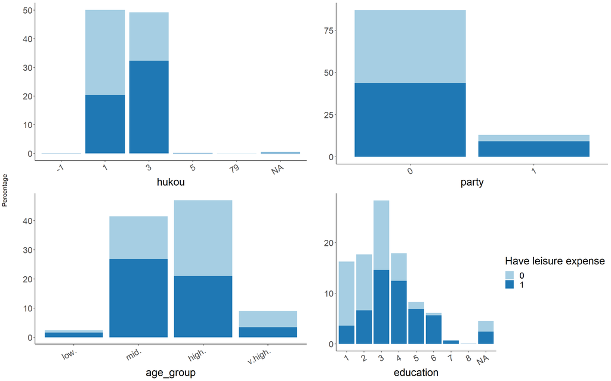

```r
#construct summary statistics by education, profit, martial status etc. to set up ggplot data infrastructure
hukou.plot <- ggplot(
  data = cfps %>% group_by(hukou, allvalue_flag) %>% summarise(percent =
                                                                        n() * 100 / nrow(cfps)) %>% mutate(group = str_c(hukou, " and leisure", allvalue_flag)),
  aes(x = hukou,
      y = percent,
      fill = allvalue_flag)
)

party.plot <- ggplot(
  data = cfps %>% group_by(party, allvalue_flag) %>% summarise(percent =
                                                                        n() * 100 / nrow(cfps)) %>% mutate(group = str_c(party, " and leisure", allvalue_flag)),
  aes(x = party,
      y = percent,
      fill = allvalue_flag)
)

age_group.plot <- ggplot(
  data = cfps %>% group_by(age_group, allvalue_flag) %>% summarise(percent =
                                                                        n() * 100 / nrow(cfps)) %>% mutate(group = str_c(age_group, " and leisure", allvalue_flag)),
  aes(x = age_group,
      y = percent,
      fill = allvalue_flag)
)

education.plot <- ggplot(
  data = cfps %>% group_by(education, allvalue_flag) %>% summarise(percent =
                                                                        n() * 100 / nrow(cfps)) %>% mutate(group = str_c(education, " and leisure", allvalue_flag)),
  aes(x = education,
      y = percent,
      fill = allvalue_flag)
)

#my function to make the plots and make them prettier
formatting <- function(plot, legend = FALSE) {
  plot <- plot +
    geom_bar(stat = "identity") +
    scale_fill_brewer(palette = "Paired") +
    ylab("") +
    labs(fill = "Have leisure expense")  +
    theme_classic() +
    theme(axis.text.x = element_text(angle = 30, hjust = 1))+
    theme(text = element_text(size = 20))
  if (legend == FALSE) {
    plot <- plot +
      theme(legend.position = "none")
  }
  return(plot)
}

#combine the 4 plots together in 1 page
grid.arrange(
  hukou.plot %>% formatting(),
  party.plot %>% formatting(),
  age_group.plot %>% formatting(),
  education.plot %>% formatting(legend = TRUE),
  left = "Percentage"
)
```

We can see older people, people without urban residence status, non-party members and people with less education generally tend to be more conservative on leisure expenses.

### MCA with categorical variables

```r
#MCA based on the data
cfps_mca <- cfps %>% select(
  age_group,
  gender,
  familysize_group,
  hukou,
  party,
  education,
  allvalue_flag,
  isei_group,
  allvalue_log_group,
  income_log_group,
  homevalue_log_group
)
mca <- MCA(
  cfps_mca,
  ncp = 5,
  method = "Burt",
  graph = FALSE
)
```

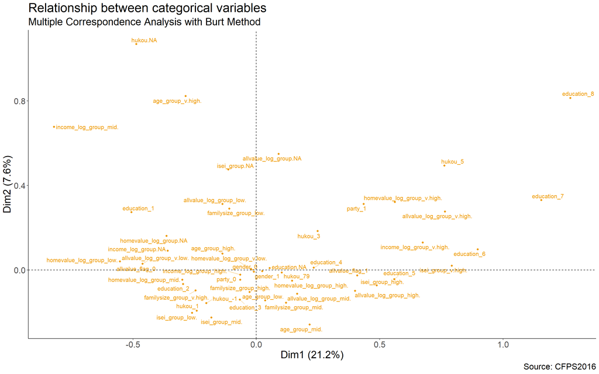

```r
#Visualize MCA outcome
fviz_mca_var(
  mca,
  axes = c(1, 2),
  choice = "var.cat",
  repel = TRUE,
  map = "symmetric",
  shape.var = "circle",
  col.var = "orange2",
  col.quali.sup = "black"
) +
  ggtitle("Relationship between categorical variables",
          subtitle = "Multiple Correspondence Analysis with Burt Method") +
  labs(caption = "Source: CFPS2016") +
  theme_classic() +
  theme(text = element_text(size = 20))
```

On top right We can see those who spend more on leisure usually have more wealth, more education, better occupations; but on the left part of X axis, those with no expense on leisure tend to be less educated, have large family size, originate from rural areas, etc.

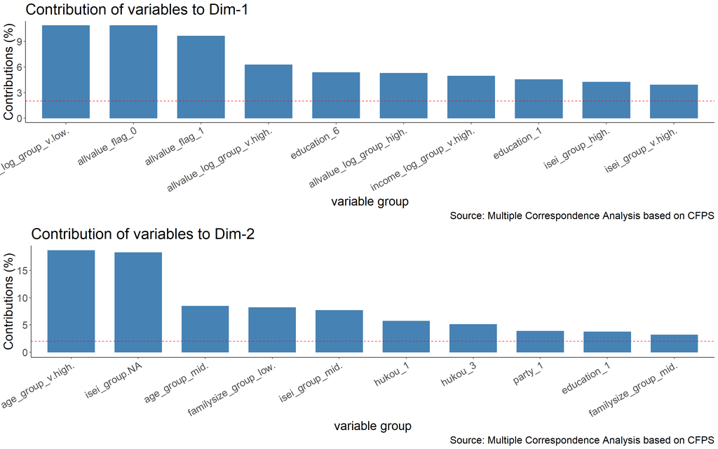

```r
#Plot contribution of variables of first dimension
contrib.plot1 <- fviz_contrib(
  mca,
  choice = "var",
  axes = 1,
  sort.val = "desc",
  top = 10
) +
  xlab("variable group") +
  labs(caption = "Source: Multiple Correspondence Analysis based on CFPS") +
  theme_classic() +
  theme(axis.text.x = element_text(angle = 30, hjust = 1))+
  theme(text = element_text(size = 20))
#Plot contribution of variables of second dimension
contrib.plot2 <- fviz_contrib(
  mca,
  choice = "var",
  axes = 2,
  sort.val = "desc",
  top = 10
) +
  xlab("variable group") +
  labs(caption = "Source: Multiple Correspondence Analysis based on CFPS") +
  theme_classic() +
  theme(axis.text.x = element_text(angle = 30, hjust = 1))+
  theme(text = element_text(size = 20))
#Show together
grid.arrange(contrib.plot1,
             contrib.plot2,
             ncol = 1)
```

## Modeling

### Missing value handling

Missingness overview

```
running C:\Users\Tianl\Documents\GitHub\Pet-projects\elder-consumption\profi> do ...


. use "data\family_merged_tidy.dta", replace

. ssc install mdesc
checking mdesc consistency and verifying not already installed...
all files already exist and are up to date.

. mdesc

    Variable    |     Missing          Total     Percent Missing
----------------+-----------------------------------------------
       resp1pid |           0          6,621           0.00
            age |           0          6,621           0.00
         gender |           0          6,621           0.00
     familysize |           0          6,621           0.00
          hukou |          34          6,621           0.51
           isei |       1,757          6,621          26.54
            egp |       1,757          6,621          26.54
          party |           0          6,621           0.00
      education |         302          6,621           4.56
       allvalue |          26          6,621           0.39
          allpr |          27          6,621           0.41
            gdp |         294          6,621           4.44
   allvalue_f~g |           0          6,621           0.00
   allvalue_log |          26          6,621           0.39
      allpr_log |          27          6,621           0.41
     income_log |          13          6,621           0.20
   homevalue_~g |          43          6,621           0.65
----------------+-----------------------------------------------
```

visualize missing patterns

```
running C:\Users\Tianl\Documents\GitHub\Pet-projects\elder-consumption\profi> do ...


. misstable patterns egp isei education

   Missing-value patterns
     (1 means complete)

              |   Pattern
    Percent   |  1  2  3
  ------------+-------------
       70%    |  1  1  1
       25     |  1  0  0
        3     |  0  1  1
        1     |  0  0  0
  ------------+-------------
      100%    |

  Variables are  (1) education  (2) egp  (3) isei
```

t-test of target variable between missing/non missing parts of variables

```
running C:\Users\Tianl\Documents\GitHub\Pet-projects\elder-consumption\profi> do ...


. foreach var of varlist egp isei education{
  2.   gen `var'_flag=1
  3.   replace `var'_flag=0 if `var'==.
  4.   ttest income_log, by(`var'_flag)
  5. }
(1,757 real changes made)

Two-sample t test with equal variances
------------------------------------------------------------------------------
   Group |     Obs        Mean    Std. Err.   Std. Dev.   [95% Conf. Interval]
---------+--------------------------------------------------------------------
       0 |   1,750    10.80046    .0263804    1.103571    10.74872     10.8522
       1 |   4,858    11.00262    .0138842    .9677173     10.9754    11.02983
---------+--------------------------------------------------------------------
combined |   6,608    10.94908    .0124167    1.009348    10.92474    10.97342
---------+--------------------------------------------------------------------
    diff |           -.2021562    .0280323               -.2571085   -.1472039
------------------------------------------------------------------------------
    diff = mean(0) - mean(1)                                      t =  -7.2116
Ho: diff = 0                                     degrees of freedom =     6606

    Ha: diff < 0                 Ha: diff != 0                 Ha: diff > 0
 Pr(T < t) = 0.0000         Pr(|T| > |t|) = 0.0000          Pr(T > t) = 1.0000
(1,757 real changes made)

Two-sample t test with equal variances
------------------------------------------------------------------------------
   Group |     Obs        Mean    Std. Err.   Std. Dev.   [95% Conf. Interval]
---------+--------------------------------------------------------------------
       0 |   1,750    10.80046    .0263804    1.103571    10.74872     10.8522
       1 |   4,858    11.00262    .0138842    .9677173     10.9754    11.02983
---------+--------------------------------------------------------------------
combined |   6,608    10.94908    .0124167    1.009348    10.92474    10.97342
---------+--------------------------------------------------------------------
    diff |           -.2021562    .0280323               -.2571085   -.1472039
------------------------------------------------------------------------------
    diff = mean(0) - mean(1)                                      t =  -7.2116
Ho: diff = 0                                     degrees of freedom =     6606

    Ha: diff < 0                 Ha: diff != 0                 Ha: diff > 0
 Pr(T < t) = 0.0000         Pr(|T| > |t|) = 0.0000          Pr(T > t) = 1.0000
(302 real changes made)

Two-sample t test with equal variances
------------------------------------------------------------------------------
   Group |     Obs        Mean    Std. Err.   Std. Dev.   [95% Conf. Interval]
---------+--------------------------------------------------------------------
       0 |     300    11.06385    .0579701    1.004071    10.94977    11.17793
       1 |   6,308    10.94362    .0127086    1.009352    10.91871    10.96853
---------+--------------------------------------------------------------------
combined |   6,608    10.94908    .0124167    1.009348    10.92474    10.97342
---------+--------------------------------------------------------------------
    diff |            .1202315    .0596305                .0033364    .2371266
------------------------------------------------------------------------------
    diff = mean(0) - mean(1)                                      t =   2.0163
Ho: diff = 0                                     degrees of freedom =     6606

    Ha: diff < 0                 Ha: diff != 0                 Ha: diff > 0
 Pr(T < t) = 0.9781         Pr(|T| > |t|) = 0.0438          Pr(T > t) = 0.0219
```

The occupation info should be MNAR

```
running C:\Users\Tianl\Documents\GitHub\Pet-projects\elder-consumption\profi> do ...


. * recoded into extreme values
. recode isei .=9999
(isei: 1757 changes made)

. recode egp .=9999
(egp: 1757 changes made)
```

Turns out education might be MAR

```
running C:\Users\Tianl\Documents\GitHub\Pet-projects\elder-consumption\profi> do ...


. * imputed with mice along with other vars
. mi set mlong

. mi register imputed income_log hukou education homevalue_log
(382 m=0 obs. now marked as incomplete)

. mi impute mvn income_log hukou education homevalue_log = age gender familysiz
> e party, add(5) rseed (0)

Performing EM optimization:
  observed log likelihood = -19872.421 at iteration 5

Performing MCMC data augmentation ...

Multivariate imputation                     Imputations =        5
Multivariate normal regression                    added =        5
Imputed: m=1 through m=5                        updated =        0

Prior: uniform                               Iterations =      500
                                                burn-in =      100
                                                between =      100

------------------------------------------------------------------
                   |               Observations per m
                   |----------------------------------------------
          Variable |   Complete   Incomplete   Imputed |     Total
-------------------+-----------------------------------+----------
        income_log |       6608           13        13 |      6621
             hukou |       6587           34        34 |      6621
         education |       6319          302       302 |      6621
     homevalue_log |       6578           43        43 |      6621
------------------------------------------------------------------
(complete + incomplete = total; imputed is the minimum across m
 of the number of filled-in observations.)
```

### Logit model

```
running C:\Users\Tianl\Documents\GitHub\Pet-projects\elder-consumption\profi> do ...


. mi estimate: logit allvalue_flag age gender familysize hukou isei party educa
> tion income_log homevalue_log if age > 60

Multiple-imputation estimates                   Imputations       =          5
Logistic regression                             Number of obs     =      1,723
                                                Average RVI       =     0.0146
                                                Largest FMI       =     0.0827
DF adjustment:   Large sample                   DF:     min       =     628.49
                                                        avg       = 213,512.39
                                                        max       = 927,440.76
Model F test:       Equal FMI                   F(   9,115582.2)  =      36.76
Within VCE type:          OIM                   Prob > F          =     0.0000

------------------------------------------------------------------------------
allvalue_f~g |      Coef.   Std. Err.      t    P>|t|     [95% Conf. Interval]
-------------+----------------------------------------------------------------
         age |  -.0163597   .0094789    -1.73   0.084    -.0349382    .0022188
      gender |  -.0903793   .1207358    -0.75   0.454    -.3270173    .1462588
  familysize |   .0341622   .0336314     1.02   0.310    -.0317571    .1000814
       hukou |   .2639428   .0724852     3.64   0.000       .12182    .4060656
        isei |   .0000283   .0000145     1.95   0.051    -8.08e-08    .0000566
       party |   .2761999   .1509301     1.83   0.067    -.0196245    .5720244
   education |   .4194005   .0540098     7.77   0.000     .3133389    .5254621
  income_log |   .7592673    .081518     9.31   0.000     .5994918    .9190428
homevalue_~g |   .0558882     .03529     1.58   0.113    -.0132799    .1250563
       _cons |  -9.400753   1.054904    -8.91   0.000    -11.46833   -7.333175
------------------------------------------------------------------------------
```

### OLS model

Among those who spend on leisure, another OLS look at factors contributing to how much is spent on leisure

```
running C:\Users\Tianl\Documents\GitHub\Pet-projects\elder-consumption\profi> do ...


. mi estimate: regress allvalue_log age gender familysize hukou isei party educ
> ation income_log homevalue_log gdp if allvalue_log>0 & age > 60

Multiple-imputation estimates                   Imputations       =          5
Linear regression                               Number of obs     =        709
                                                Average RVI       =     0.0101
                                                Largest FMI       =     0.0451
                                                Complete DF       =        698
DF adjustment:   Small sample                   DF:     min       =     503.15
                                                        avg       =     659.85
                                                        max       =     695.74
Model F test:       Equal FMI                   F(  10,  694.2)   =      16.86
Within VCE type:          OLS                   Prob > F          =     0.0000

------------------------------------------------------------------------------
allvalue_log |      Coef.   Std. Err.      t    P>|t|     [95% Conf. Interval]
-------------+----------------------------------------------------------------
         age |  -.0609219   .0107349    -5.68   0.000     -.081999   -.0398448
      gender |  -.1370669   .1317106    -1.04   0.298    -.3956647     .121531
  familysize |  -.0598186   .0385448    -1.55   0.121    -.1355017    .0158646
       hukou |   .2654156   .0902912     2.94   0.003     .0880213    .4428098
        isei |  -3.91e-06   .0000162    -0.24   0.809    -.0000356    .0000278
       party |   .1802943   .1501072     1.20   0.230    -.1144246    .4750132
   education |    .103277   .0525457     1.97   0.050     .0000825    .2064716
  income_log |   .4987787   .0907413     5.50   0.000     .3206103    .6769471
homevalue_~g |   .0753575   .0373376     2.02   0.044     .0020415    .1486736
         gdp |   .0000334   .0000166     2.01   0.045     7.72e-07     .000066
       _cons |   4.343652   1.193261     3.64   0.000     2.000794    6.686511
------------------------------------------------------------------------------
```

Same formulation targeting at the proportion of leisure of total consumption

```
running C:\Users\Tianl\Documents\GitHub\Pet-projects\elder-consumption\profi> do ...


. mi estimate: regress allpr_log age gender familysize hukou isei party educati
> on income_log homevalue_log gdp if allpr_log>0 & age > 60

Multiple-imputation estimates                   Imputations       =          5
Linear regression                               Number of obs     =        709
                                                Average RVI       =     0.0116
                                                Largest FMI       =     0.0601
                                                Complete DF       =        698
DF adjustment:   Small sample                   DF:     min       =     420.69
                                                        avg       =     649.87
                                                        max       =     695.71
Model F test:       Equal FMI                   F(  10,  693.6)   =       7.90
Within VCE type:          OLS                   Prob > F          =     0.0000

------------------------------------------------------------------------------
   allpr_log |      Coef.   Std. Err.      t    P>|t|     [95% Conf. Interval]
-------------+----------------------------------------------------------------
         age |  -.0283335   .0062248    -4.55   0.000    -.0405552   -.0161118
      gender |  -.0797097    .076452    -1.04   0.297    -.2298141    .0703946
  familysize |  -.1009355   .0223579    -4.51   0.000    -.1448349    -.057036
       hukou |   .1025266    .052806     1.94   0.053    -.0012699    .2063232
        isei |  -8.53e-06   9.39e-06    -0.91   0.364     -.000027    9.90e-06
       party |  -.0008418   .0871426    -0.01   0.992    -.1719369    .1702532
   education |   .0499603   .0305298     1.64   0.102    -.0099993    .1099199
  income_log |   .1032532   .0526464     1.96   0.050     -.000116    .2066224
homevalue_~g |   .0447691   .0217332     2.06   0.040     .0020907    .0874476
         gdp |   3.93e-06   9.63e-06     0.41   0.683     -.000015    .0000228
       _cons |   1.968048    .691979     2.84   0.005     .6094206    3.326675
------------------------------------------------------------------------------
```